# Morfologia, luento 10

Juho Härme

Pinni B 5004, juho.harme@uta.fi

# Instrumentaali

- жарить над раскалёнными углями.
- встанете *перед картиной* и будете думать: “Так… вот она, это же она…”
- Под пиджаком у него была только рваная сетчатая майка
- Почему-то я вспомнил, как мы шли сквером и спорили
- Кругом золотились осенние поля, мы шли дорогой, по которой…
- Он шёл лесом, и ему представлялось: вот уж нет его…
- перед сном / рассветом / тем, как…
- утром, вечером, днём, летом, зимой, целыми вечерами
- прошлой ночью, следующей ночью, прошлой осенью..

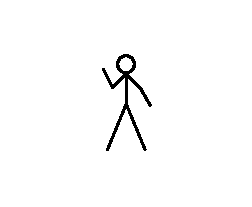

- Я молча махнул рукой и пошёл прочь.
- Принюхиваясь, очень смешно двигают носом и мигают глазами.
- На одной из них стоят два гражданина и размахивают чемоданами.

# Mikä merkitys?

- Мы видели канал, покрытый льдом.
- Таким образом, профилактика экстремизма, проводимая государством, нарушает права человека и должна быть признана неконституционной
- Квартиры, которые у нас строятся *компанией* «Стройметресурс», отличаются хорошей планировкой.
- Ветром унесло лодку
- Тротуар залило водой

# Verbin täydennyksenä

- *владеть, править, управлять, ползоваться, распологать, распоряжаться, руководит, заведовать.*
- *восхищаться, гордиться, хвастаться, интересоваться, увлекаться, наслаждаться, обходиться.*
- *делиться, обмениваться.*
- *болеть, страдать, жертвовать, рисковать*
- *торговать, прославляться, заниматсья, увлекаться*.

# Tehtävä

Tehtävä 1

# Prepositionaali

- 28 июня в Нью-Йорке открывается основная ежегодная сессия ЭКОСОС
- Русские и немцы впервые устроили перемирие в апреле 1915 года
- В связи с.. В частности… в начале..
- На работе… На поезде…
- На прошлой неделе в Москве состоялся один из самых представительных ежегодных экономических форумов
- На днях дочка сказала что в школе однокласники начали курить
- Варить хаш без соли на слабом огне

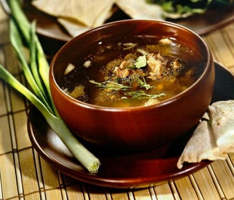

# Harvinaisempia

- Объявление при входе в студенческую столовую: “Пожалуйста, не подбирайте крошки со столов ― не бесите тараканов!”
- При подключении к общественным точкам WiFi пользователи обязаны предоставлять свои паспортные данные.
- В нашей стране тоже на изучение экстрасенсов выделялись (особенно при Ельцине) громадные средства.
- По завершении лекции гость ответил на вопросы студентов и журналистов

# Kontrastiivinen sivupolku

[Moodle](https://learning2.uta.fi/course/view.php?id=8679)

# Prepositionaali täydennyksenä

- играть + на
- И тем не менее я был совершенно уверен в своей правоте.
- Можно сказать что он ещё не *разбирается в жизни*, на неи табачная компания деньги делает, на его здоровье, а он не понимает…
- Для этого достаточно *разобраться в причинах того*, почему Россия в последние четыре года заметно упрочила свою репутацию ответственного игрока на международной арене.
- И зачем *разбираться в музыке*, когда можно просто петь.
- Тогда Хлопонин пообещал “разобраться” с ними в том случае, если они будут вести себя “неконструктивно”.